CS F364: Design & Analysis of Algorithms

# Closest Pair of Points in 2D

Lecture 6 |2026-05-21

Dr. Tulasimohan Molli BITS Pilani, Hyderabad Campus

# Divide and conquer algorithm

- Divide and conquer algorithm

## Closest Pair of Points

## Closest pair of points: Algorithm

**Divide.** Draw vertical line $L$ with $\approx n/2$ points on each side.

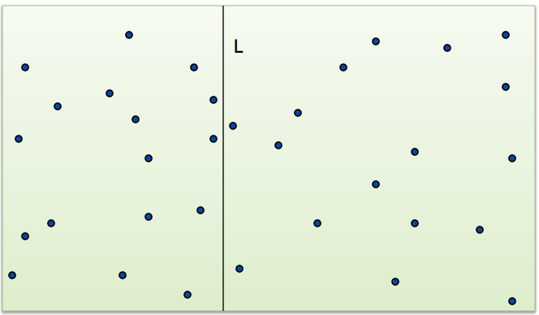

Divide with vertical line

## Closest pair of points: Algorithm

**Divide.** Draw vertical line $L$ with $\approx n/2$ points on each side.  
**Conquer.** Find closest pair on each side, recursively.

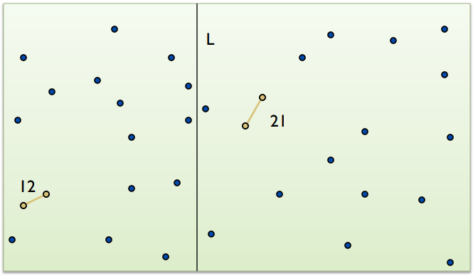

Conquer recursively

## Closest pair of points: Algorithm

**Divide.** Draw vertical line $L$ with $\approx n/2$ points on each side.  
**Conquer.** Find closest pair on each side, recursively.  
**Combine.** Find closest pair with one point in each side.  
Return best of 3 solutions.

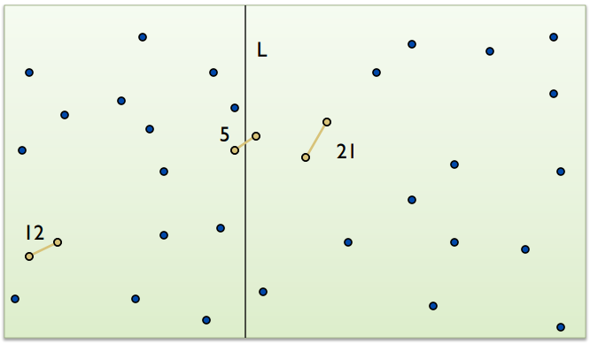

Combine step

## Closest pair of points: Algorithm

Find closest pair with one point in each side, assuming distance $< \delta = \min\{d_1, d_2\}$.  
Return best of 3 solutions.

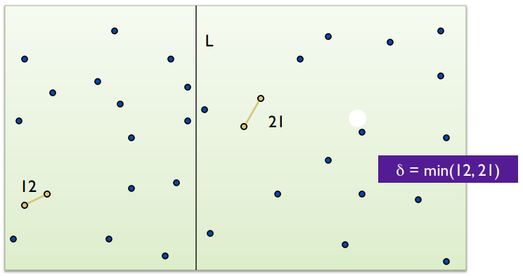

Finding crossing pair

## Closest pair of points: Algorithm

Find closest pair with one point in each side, assuming distance $< \delta = \min\{d_1, d_2\}$.  
Return best of 3 solutions.

**Observation:** Suffices to consider points within $\delta$ of line $L$.

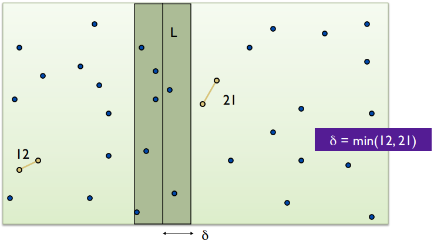

Points within $\delta$ of L

## Closest pair of points: Algorithm

Find closest pair with one point in each side, assuming distance $< \delta = \min\{d_1, d_2\}$.  
Return best of 3 solutions.

**Observation:** Suffices to consider points within $\delta$ of line $L$.  
**Almost the one dimensional problem:** Sort points in $2\delta$-strip by their $y$ coordinate.  
Only check points within 8 in sorted list!

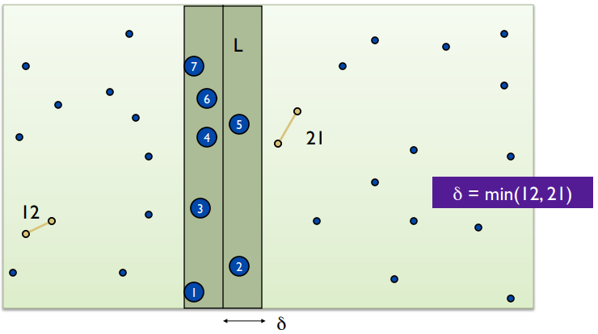

Checking points in strip

## Closest pair of points: Algorithm

**Def.** Let $p_i$ have the $i^{th}$ smallest $y$-coordinate among points in the $2\delta$-width-strip.  
**Claim.** If $|i-j| > 8$, then the distance between $p_i$ and $p_j$ is $> \delta$.  
**Proof.** No two points lie in the same $\delta/2$-by-$\delta/2$ square!

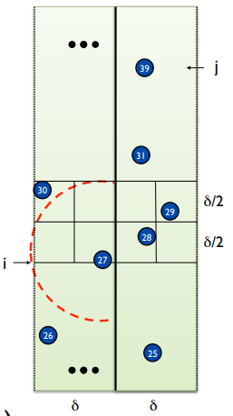

$\delta/2$ box argument

## Closest pair of points: Algorithm

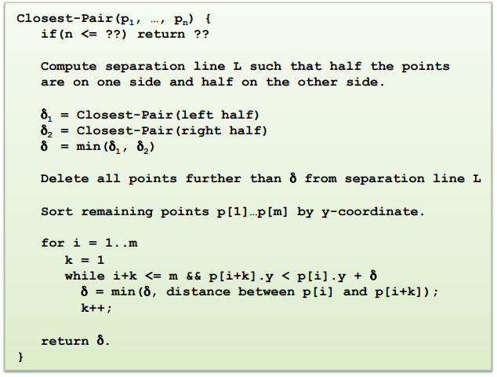

Full algorithm

## Closest Pair Analysis

## closest pair of points: Analysis

**Analysis-1:** Let $D(n)$ be the number of pairwise distance calculations in the Closest-Pair Algorithm when run on $n \geq 1$ points.

$$D(n) \leq \begin{cases}
0, & n=1\\
2D(n/2) + 7n, & n > 1.
\end{cases}$$

$\implies D(n) = O(n\log{n})$.

This is the number of distance computations.

## closest pair of points: Analysis

**Analysis-2:** Let $C(n)$ be the number of comparisons in the Closest-Pair Algorithm when run on $n \geq 1$ points.

$$C(n) \leq \begin{cases}
0, & n=1\\
2C(n/2) + O(n\log{n}), & n > 1.
\end{cases}$$

$\implies C(n) = O(n\log^2{n})$.

This is the number of comparisons.

Can we reduce the time complexity to $O(n\log{n})$?

- Sort all points based on $x$-coordinate initially (one time only) – $O(n\log{n})$
- Sort all points based on $y$-coordinate initially (one time only) – $O(n\log{n})$
- Create the $y$-sorted list of points in the $\delta$-strip by merging two sorted lists – $O(n)$

Thus, total complexity can be reduced to $O(n\log{n})$.

## References:

- Michael T. Goodrich and Roberto Tamassia, “Algorithm Design Foundations, Analysis, and Internet Examples”, *Wiley Student Edition*.
- Jon Kleinberg and Eva Tardos, “Algorithm Design”, *Pearson Publishers*.
- Thomas H. Chorman, Charles E. Leiserson, Ronald L. Rivest and Clifford Stein, “Introduction to algorithms”, *MIT Press Publishers*.
- Sanjoy Dasgupta, Umesh Vazirani, Christos Papadimitriou, “Algorithms”, *McGraw-Hill Education Publishers*.